# Using GIT with GitHub

Today we will be working with one of the most popular version control systems called [Git](http://git-scm.com/). Like [R](http://www.r-project.org), [Git](http://git-scm.com/) is free and open source, decreasing the boundaries for global collaborations. We'll be operating [Git](http://git-scm.com/) from Terminal and using [GitHub](https://github.com/) as our remote online repository.

### GIT works in four main layers:

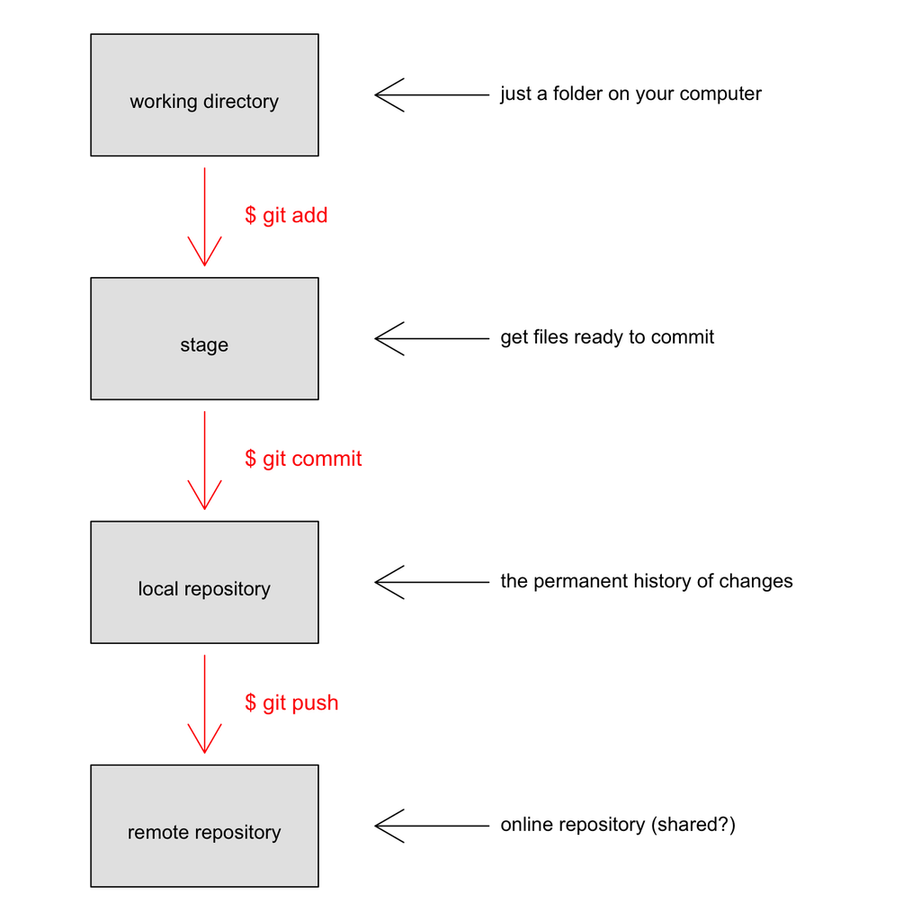

### Step 1: create [GitHub](https://github.com/) account

- using your academic account has advantages - free private repositories

### Step 2: set up global user configurations on Terminal

- `git config --global user.name "your desired username"`
- `git config --global user.email "your email (academic has advantages)"`

### Step 3: create a new local repo in shell dir:

```r
$ git init
```

### Step 4: check status of repo:

```r
$ git status
```

### Step 5: create a new file README.md and add it (stage) to the local repo:

```r
$ git add filename

#conversely you can add all files (and deletions) by typing
$ git add --all
```

### Step 6: recheck status

### Step 7: ready to commit the change?

```r
$ git commit -m 'your message here'
```

### Step 8: check commit's history:

```r
$ git log
```

### Step 9: we want you to gather in pairs, one student will be *student A*, and the other *student B*. Let's collaborate with [GitHub](https://github.com/):

- student A:
  - create repo on [GitHub](https://github.com/)
  - copy and paste last two lines of code from [GitHub](https://github.com/) to add remote/push
  - look at repo page on [GitHub](https://github.com/)
  - add person B as a collaborator (settings > collaborators)
- student B:
  - clone person A's repo
    - at the bottom right side of the repo page, click on 'You can clone with HTTPS' and then copy the link shown right above
  - on your machine, open the repo folder, find the README.md file, open in RStudio and make a change to it
  - open Terminal and stage the file by typing `$ git add`
  - commit the change with the message `$ git commit -m 'changed README'`
  - push to the repo on GitHub typing `$ git push`
- student A:
  - pull the latest changes made by student B by typing `$ git pull`